# Assignment 3

Jordi Florit Ensenyat, Josep Gabriel Fornés Reynés, Pau Girón Rodríguez

2024-11-25

## **1. Introduction**

This assignment aims to build predictive models to classify the loan status variable (approved/not approved) for potential applicants using the loan_data.csv dataset. The dataset, available on Kaggle, is a synthetic version inspired by the original Credit Risk dataset and enriched with additional variables based on Financial Risk for Loan Approval data. The analysis will be structured as follows:

- **Data Analysis**: Analyze key features, distribution patterns, relationships, plots, missing data, and outliers to better understand credit risk factors.
- **Data Processing**: Prepare the data by handling missing values, outliers, and normalizing features to ensure the dataset is ready for modeling.
- **Classification Methods**: Evaluate different classification methods for modeling loan approval, using various structures and parameters, and compare the models obtained.

This structured approach ensures a comprehensive analysis and comparison of different models to identify the most effective one for predicting loan approval.

### **1.1. Dataset Information**

The dataset, available on Kaggle (https://www.kaggle.com/datasets/taweilo/loan-approval-classification-data) is a synthetic version inspired by the original Credit Risk dataset and enriched with additional variables based on Financial Risk for Loan Approval data. SMOTENC was used to simulate new data points to enlarge the instances. The dataset is structured for both categorical and continuous features.

### **1.2. Variable Information**

The dataset contains 45,000 records and 14 variables. Below is a detailed description of each variable:

*1. person age*: Age of the person (numeric)

*2. person gender*: Gender of the person (categorical: female, male)

*3. person education:* Highest education level (categorical: Associate, Bachelor, Doctorate, High School, Master)

*4. person income:* Annual income (numeric)

*5. person emp exp:* Years of employment experience (integer)

*6. person home ownership:* Home ownership status (categorical: MORTGAGE, OTHER, OWN, RENT)

*7. loan amnt:* Loan amount requested (numeric)

*8. loan intent:* Purpose of the loan (categorical: DEBTCONSOLIDATION, EDUCATION, HOMEIMPROVEMENT, MEDICAL, PERSONAL, VENTURE)

*9. loan int rate:* Loan interest rate (numeric)

*10. loan percent income:* Loan amount as a percentage of annual income (numeric)

*11. cb person cred hist length:* Length of credit history in years (numeric)

*12. credit score:* Credit score of the person (integer)

*13. previous loan defaults on file:* Indicator of previous loan defaults (categorical: No, Yes)

#### **Class label (target variable)**

*14. loan status:* Loan approval status (integer 1 = approved; 0 = rejected)

### **1.3. Research Question**

Utilize the data provided to build predictive models to classify the loan status variable (approved/not approved) for potential applicants. To answer this question you will:

*a) (5 POINTS) Perform Explanatory Data Analysis:* analyze key features, distribution patterns, relationships, plots, missing data, outliers, … to better understand credit risk factors.

*b) (20 POINTS) Consider different classification methods for modelling loan approval.* For each method, use different structures and/or parameters, different training/testing sets, compare the different models obtained and comment your results. Which model is the “best”?

## **2. Data Analisis**

### **2.1. Importing Data**

First of all, we have to import our data. Here, we are loading the necessary libraries and reading the CSV file containing the loan data.

```r
# Load the necessary libraries and read the CSV file containing the loan data
library(tidyverse)
```

```r
library(ggcorrplot)
library(gridExtra)
library(ggplot2)
library(dplyr)
library(e1071)
library(caret)
library(gmodels)
library(rpart)
library(rpart.plot)
data <- read.table("loan_data.csv", header = TRUE, sep = ",")
```

This is one simple example of the dataset:

```r
# Display the structure of the dataset
str(data)
```

```
## 'data.frame':    45000 obs. of  14 variables:
##  $ person_age                    : num  22 21 25 23 24 21 26 24 24 21 ...
##  $ person_gender                 : chr  "female" "female" "female" "female" ...
##  $ person_education              : chr  "Master" "High School" "High School" "Bachelor" ...
##  $ person_income                 : num  71948 12282 12438 79753 66135 ...
##  $ person_emp_exp                : int  0 0 3 0 1 0 1 5 3 0 ...
##  $ person_home_ownership         : chr  "RENT" "OWN" "MORTGAGE" "RENT" ...
##  $ loan_amnt                     : num  35000 1000 5500 35000 35000 2500 35000 35000 35000 1600 ...
##  $ loan_intent                   : chr  "PERSONAL" "EDUCATION" "MEDICAL" "MEDICAL" ...
##  $ loan_int_rate                 : num  16 11.1 12.9 15.2 14.3 ...
##  $ loan_percent_income           : num  0.49 0.08 0.44 0.44 0.53 0.19 0.37 0.37 0.35 0.13 ...
##  $ cb_person_cred_hist_length    : num  3 2 3 2 4 2 3 4 2 3 ...
##  $ credit_score                  : int  561 504 635 675 586 532 701 585 544 640 ...
##  $ previous_loan_defaults_on_file: chr  "No" "Yes" "No" "No" ...
##  $ loan_status                   : int  1 0 1 1 1 1 1 1 1 1 ...
```

The summary data. The summary() function gives a statistical summary of each column, including minimum, maximum, mean, and quartiles.

```r
# Display a statistical summary of each column, including minimum, maximum, mean, and quartiles
summary(data)
```

```
##    person_age     person_gender      person_education   person_income
##  Min.   : 20.00   Length:45000       Length:45000       Min.   :   8000
##  1st Qu.: 24.00   Class :character   Class :character   1st Qu.:  47204
##  Median : 26.00   Mode  :character   Mode  :character   Median :  67048
##  Mean   : 27.76                                         Mean   :  80319
##  3rd Qu.: 30.00                                         3rd Qu.:  95789
##  Max.   :144.00                                         Max.   :7200766
##  person_emp_exp   person_home_ownership   loan_amnt     loan_intent
##  Min.   :  0.00   Length:45000          Min.   :  500   Length:45000
##  1st Qu.:  1.00   Class :character      1st Qu.: 5000   Class :character
##  Median :  4.00   Mode  :character      Median : 8000   Mode  :character
##  Mean   :  5.41                         Mean   : 9583
##  3rd Qu.:  8.00                         3rd Qu.:12237
##  Max.   :125.00                         Max.   :35000
##  loan_int_rate   loan_percent_income cb_person_cred_hist_length  credit_score
##  Min.   : 5.42   Min.   :0.0000      Min.   : 2.000             Min.   :390.0
##  1st Qu.: 8.59   1st Qu.:0.0700      1st Qu.: 3.000             1st Qu.:601.0
##  Median :11.01   Median :0.1200      Median : 4.000             Median :640.0
##  Mean   :11.01   Mean   :0.1397      Mean   : 5.867             Mean   :632.6
##  3rd Qu.:12.99   3rd Qu.:0.1900      3rd Qu.: 8.000             3rd Qu.:670.0
##  Max.   :20.00   Max.   :0.6600      Max.   :30.000             Max.   :850.0
##  previous_loan_defaults_on_file  loan_status
##  Length:45000                   Min.   :0.0000
##  Class :character               1st Qu.:0.0000
##  Mode  :character               Median :0.0000
##                                 Mean   :0.2222
##                                 3rd Qu.:0.0000
##                                 Max.   :1.0000
```

### **2.2. Missing Values**

```r
# Identify missing values
colSums(is.na(data))
```

```
##                     person_age                  person_gender
##                              0                              0
##               person_education                  person_income
##                              0                              0
##                 person_emp_exp          person_home_ownership
##                              0                              0
##                      loan_amnt                    loan_intent
##                              0                              0
##                  loan_int_rate            loan_percent_income
##                              0                              0
##     cb_person_cred_hist_length                   credit_score
##                              0                              0
## previous_loan_defaults_on_file                    loan_status
##                              0                              0
```

The function counts the number of missing values in each column of the dataframe. We can see that there are no missing values. This confirms that there are no NA values in the dataset, which is crucial to avoid errors in further analysis.

### **2.3. Outliers**

As we can see into the summary, there are some **unusual data (outliers)**:

*· person_age*: the maximum age of a person in this column is 144, which is not very credible and strange data. So now, we are going to show the possible outliers into the person_age data. Since we are talking in terms of requesting loans, we are going to assume that people over 80 years old are not going to request a loan. Now let’s visualize people over 80 years old.

```r
# Filter rows directly to identify potential outliers in person_age
outliers_age <- data[data$person_age > 80, ]

# Display the first few rows
outliers_age
```

```
##       person_age person_gender person_education person_income person_emp_exp
## 82           144          male         Bachelor        300616            125
## 184          144          male        Associate        241424            121
## 576          123        female      High School         97140            101
## 748          123          male         Bachelor         94723            100
## 32298        144        female        Associate       7200766            124
## 32417         94          male      High School         29738             76
## 32507         84          male      High School        114705             61
## 37931        116          male         Bachelor       5545545             93
## 38114        109          male      High School       5556399             85
##       person_home_ownership loan_amnt loan_intent loan_int_rate
## 82                     RENT      4800     VENTURE         13.57
## 184                MORTGAGE      6000   EDUCATION         11.86
## 576                    RENT     20400   EDUCATION         10.25
## 748                    RENT     20000     VENTURE         11.01
```

[output cut: 25 more lines]

*· person_emp_exp*: there is a person with 125 years of work experience, which makes us think that it is unusual and erroneous data. Given that work experience generally begins between 15 and 25 years of age, and considering an average retirement around 65 years of age, a reasonable range for work experience could be 0 to 50 years. Now let’s look at the people who are in a higher rank.

```r
# Filtrar filas directamente
outliers_emp_exp <- data[data$person_emp_exp > 50, ]

# Mostrar las primeras filas
outliers_emp_exp
```

```
##       person_age person_gender person_education person_income person_emp_exp
## 82           144          male         Bachelor        300616            125
## 184          144          male        Associate        241424            121
## 576          123        female      High School         97140            101
## 748          123          male         Bachelor         94723            100
## 32298        144        female        Associate       7200766            124
## 32356         78          male        Associate         58463             57
## 32417         94          male      High School         29738             76
## 32423         80          male      High School         77894             62
## 32507         84          male      High School        114705             61
## 32535         76        female         Bachelor         90934             58
## 37931        116          male         Bachelor       5545545             93
## 38114        109          male      High School       5556399             85
##       person_home_ownership loan_amnt loan_intent loan_int_rate
## 82                     RENT      4800     VENTURE         13.57
```

[output cut: 37 more lines]

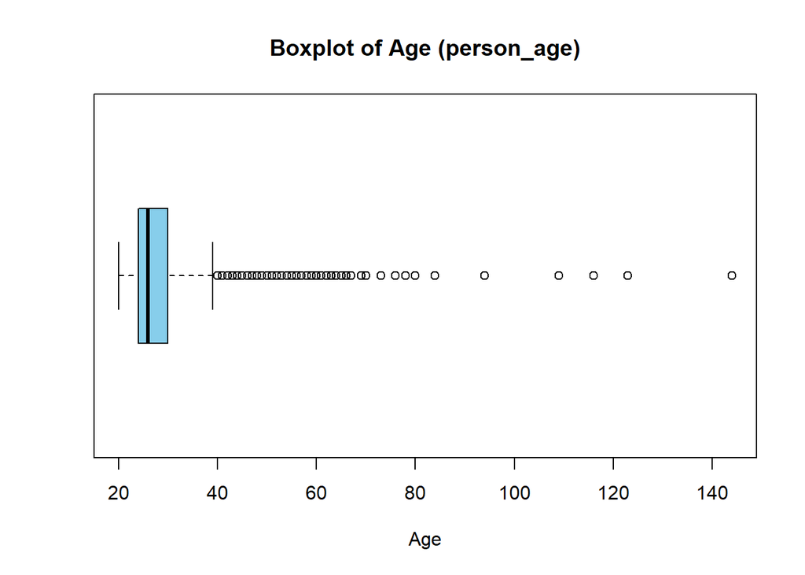

```r
# Boxplot for person_age
boxplot(data$person_age,
        main = "Boxplot of Age (person_age)",
        xlab = "Age",
        horizontal = TRUE,
        col = "skyblue")
```

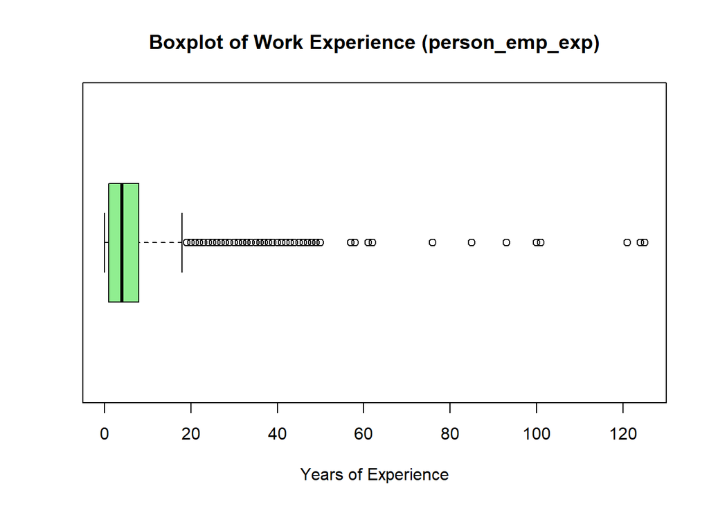

```r
# Boxplot for person_emp_exp
boxplot(data$person_emp_exp,
        main = "Boxplot of Work Experience (person_emp_exp)",
        xlab = "Years of Experience",
        horizontal = TRUE,
        col = "lightgreen")
```

After analyzing the previous tables, we have drawn the following conclusions regarding the identified outliers:

**1. Overlap between age and work experience:**

· There are 9 individuals who have both more than 80 years of age and more than 50 years of work experience.

**2. Outlier classification among these 9 individuals:**

· Out of these 9 individuals, 7 are considered outliers, as their age and work experience values are unusually high and implausible.

· Among the remaining two individuals:

· The person with 84 years old and 61 years of work experience seems reasonable within the context and will not be considered an outlier.

· The person with 94 years old and 76 years of work experience appears less credible, although theoretically possible. However, we decided to classify this individual as an outlier due to its high improbability.

**3. Individuals with extreme values individually (age or work experience):**

· Those with less than 80 years of age or less than 50 years of work experience are not considered outliers. While their data may seem unusual, they will remain in the analysis as potentially valid entries.

**4. Impact on modeling:**

· The values identified as non-outliers will be included in the predictive models, while extreme values classified as outliers will be removed to avoid biases in the analysis.

```r
# Filter values considered as non-outliers
data_cleaned <- data %>%
  filter(
    # Keep those with work experience <= 50 or plausible exceptional cases
    !(person_age >= 94 & person_emp_exp >= 76), # Case considered outlier
  )

# Verify the cleaned data
summary(data_cleaned)
```

```
##    person_age    person_gender      person_education   person_income
##  Min.   :20.00   Length:44992       Length:44992       Min.   :   8000
##  1st Qu.:24.00   Class :character   Class :character   1st Qu.:  47197
##  Median :26.00   Mode  :character   Mode  :character   Median :  67046
##  Mean   :27.75                                         Mean   :  79910
##  3rd Qu.:30.00                                         3rd Qu.:  95779
##  Max.   :84.00                                         Max.   :2448661
##  person_emp_exp   person_home_ownership   loan_amnt     loan_intent
##  Min.   : 0.000   Length:44992          Min.   :  500   Length:44992
##  1st Qu.: 1.000   Class :character      1st Qu.: 5000   Class :character
##  Median : 4.000   Mode  :character      Median : 8000   Mode  :character
##  Mean   : 5.393                         Mean   : 9583
##  3rd Qu.: 8.000                         3rd Qu.:12237
##  Max.   :62.000                         Max.   :35000
##  loan_int_rate   loan_percent_income cb_person_cred_hist_length  credit_score
##  Min.   : 5.42   Min.   :0.0000      Min.   : 2.000             Min.   :390.0
##  1st Qu.: 8.59   1st Qu.:0.0700      1st Qu.: 3.000             1st Qu.:601.0
##  Median :11.01   Median :0.1200      Median : 4.000             Median :640.0
##  Mean   :11.01   Mean   :0.1397      Mean   : 5.866             Mean   :632.6
##  3rd Qu.:12.99   3rd Qu.:0.1900      3rd Qu.: 8.000             3rd Qu.:670.0
##  Max.   :20.00   Max.   :0.6600      Max.   :30.000             Max.   :784.0
##  previous_loan_defaults_on_file  loan_status
##  Length:44992                   Min.   :0.0000
##  Class :character               1st Qu.:0.0000
##  Mode  :character               Median :0.0000
##                                 Mean   :0.2223
##                                 3rd Qu.:0.0000
##                                 Max.   :1.0000
```

```r
# Save the cleaned data
write.csv(data_cleaned, "loan_data_cleaned.csv", row.names = FALSE)
```

With this new data, we can see that there is a person whose *person_income is 2448661*. This is a very high value, but we can consider it valid, because it is possible.

### **2.4. Relationships**

Now we are going to identify **highly correlated variables**. This is important because highly correlated variables can cause problems in certain models. Correlation can only be calculated between numeric variables. Values range from -1 (perfect negative correlation) to 1 (perfect positive correlation). Values close to 0 indicate little or no variation. It is not desirable to have correlated features if we are modeling the data using linear regressions.

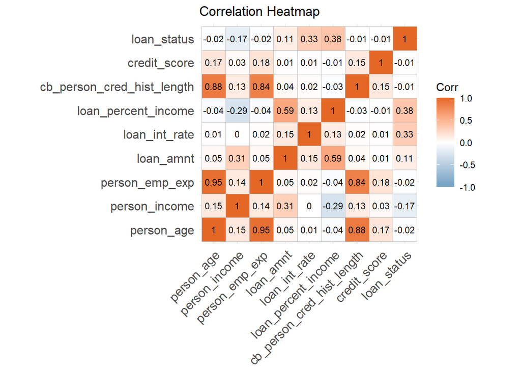

```r
# Calculate correlations between numeric variables
numeric_data <- data_cleaned %>% select_if(is.numeric)
corr_matrix <- cor(numeric_data, use = "complete.obs")

# Plot the correlation heatmap
ggcorrplot(corr_matrix, method = "square", type = "full", lab = TRUE, lab_size = 3,
           colors = c("#6D9EC1", "white", "#E46726"), title = "Correlation Heatmap")
```

We are going to carry out the study of the previous correlations.

- **Stronger correlations**:
  - **cb_person_cred_hist_length and person_age**: correlation of 0.88, which suggests that the older the person is, the longer their credit history is. This is to be expected, since older people tend to have a longer financial history.
  - **person_age and person_emp_exp**: correlation of 0.95 is an extremely strong correlation between age and work experience. This makes sense, since generally, the older you are, the more time you have spent working.
  - **person_emp_exp and cb_person_cred_hist_length**: work experience is also highly related to credit history (0.84). This reinforces the idea that these three variables (person_age, person_emp_exp, cb_person_cred_hist_length) contain redundant information, since they all represent, in some way, time in the work or financial system.

This strong correlation suggests that these variables are related, and it may be redundant to include both in a predictive model. That can cause multicollinearity problems. It is recommended to delete one of them or transform them.

As this separation is only recommended for linear regression models, we are not going to perform the separation.

- **Moderate correaltions**:
  - **loan_amnt and loan_percent_income**: correlation of 0.59, this implies that people who request larger loans tend to dedicate a greater percentage of their income to repaying them.

They appear to be important variables, as they have moderate correlations with loan status (loan_status) and with each other. These variables are relevant to predict the status of the loan.

Weak correlations:

- **loan_amnt and person_income**: there is a weak but positive correlation (0.31) between loan amount and income. This suggests that income is a relevant factor, but not a determining factor for the amount requested.
- **person_income and cb_person_cred_hist_length**: correlation of 0.13, it could be because having a long credit history is not necessarily linked to high income, but rather to access to credit.

Weak or non-existent correlations:

Now we are going to analyze the variables to find out if they have little or no variance:

```r
# Identify variables with low variance
sapply(data_cleaned, function(x) length(unique(x)))
```

```
##                     person_age                  person_gender
##                             55                              2
##               person_education                  person_income
##                              5                          33983
##                 person_emp_exp          person_home_ownership
##                             55                              4
##                      loan_amnt                    loan_intent
##                           4481                              6
##                  loan_int_rate            loan_percent_income
##                           1302                             64
##     cb_person_cred_hist_length                   credit_score
##                             29                            334
## previous_loan_defaults_on_file                    loan_status
##                              2                              2
```

Most variables with low variance are categorical variables. Let’s see representations of these variables:

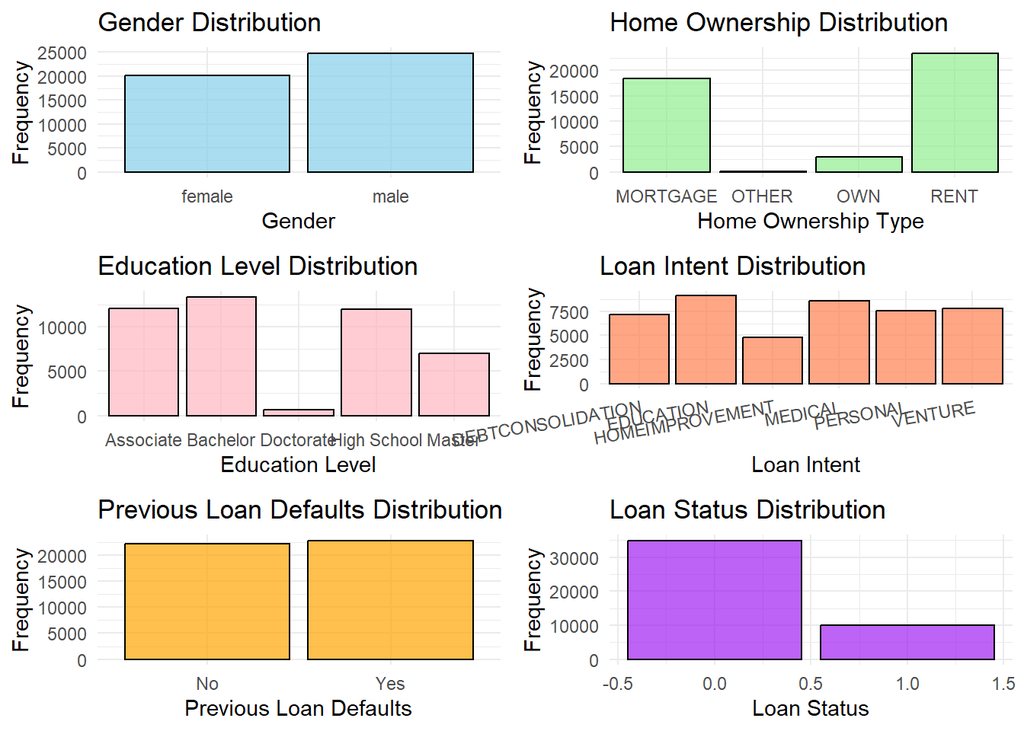

```r
# Bar plot for gender distribution
plot_gender <- ggplot(data_cleaned, aes(x = person_gender)) +
  geom_bar(fill = "skyblue", color = "black", alpha = 0.7) +
  labs(
    title = "Gender Distribution",
    x = "Gender",
    y = "Frequency"
  ) +
  theme_minimal()

# Bar plot for home ownership status
plot_home <- ggplot(data_cleaned, aes(x = person_home_ownership)) +
  geom_bar(fill = "lightgreen", color = "black", alpha = 0.7) +
  labs(
    title = "Home Ownership Distribution",
    x = "Home Ownership Type",
    y = "Frequency"
  ) +
  theme_minimal()

# Bar plot for education level
plot_education <- ggplot(data_cleaned, aes(x = person_education)) +
  geom_bar(fill = "lightpink", color = "black", alpha = 0.7) +
  labs(
    title = "Education Level Distribution",
    x = "Education Level",
    y = "Frequency"
  ) +
  theme_minimal()

# Bar plot for loan intent
plot_intent <- ggplot(data_cleaned, aes(x = loan_intent)) +
  geom_bar(fill = "coral", color = "black", alpha = 0.7) +
  labs(
    title = "Loan Intent Distribution",
    x = "Loan Intent",
    y = "Frequency"
  ) +
  theme_minimal() +
  theme(axis.text.x = element_text(angle = 10, hjust = 1))

# Bar plot for previous loan defaults
plot_defaults <- ggplot(data_cleaned, aes(x = previous_loan_defaults_on_file)) +
  geom_bar(fill = "orange", color = "black", alpha = 0.7) +
  labs(
    title = "Previous Loan Defaults Distribution",
    x = "Previous Loan Defaults",
    y = "Frequency"
  ) +
  theme_minimal()

# Bar plot for loan status
plot_status <- ggplot(data_cleaned, aes(x = loan_status)) +
  geom_bar(fill = "purple", color = "black", alpha = 0.7) +
  labs(
    title = "Loan Status Distribution",
    x = "Loan Status",
    y = "Frequency"
  ) +
  theme_minimal()

# Combine all the plots in a grid
grid.arrange(
  plot_gender, plot_home, plot_education,
  plot_intent, plot_defaults, plot_status,
  ncol = 2
)
```

Also we can see some variable distribution.

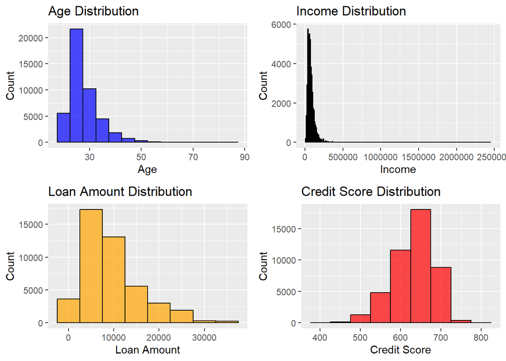

```r
# Distribution of Key Features
# Age Distribution
age_plot <- ggplot(data_cleaned, aes(x = person_age)) +
  geom_histogram(binwidth = 5, fill = "blue", color = "black", alpha = 0.7) +
  ggtitle("Age Distribution") +
  xlab("Age") +
  ylab("Count")

# Income Distribution
income_plot <- ggplot(data_cleaned, aes(x = person_income)) +
  geom_histogram(binwidth = 10000, fill = "green", color = "black", alpha = 0.7) +
  ggtitle("Income Distribution") +
  xlab("Income") +
  ylab("Count")

# Loan Amount Distribution
loan_amount_plot <- ggplot(data_cleaned, aes(x = loan_amnt)) +
  geom_histogram(binwidth = 5000, fill = "orange", color = "black", alpha = 0.7) +
  ggtitle("Loan Amount Distribution") +
  xlab("Loan Amount") +
  ylab("Count")

# Credit Score Distribution
credit_score_plot <- ggplot(data_cleaned, aes(x = credit_score)) +
  geom_histogram(binwidth = 50, fill = "red", color = "black", alpha = 0.7) +
  ggtitle("Credit Score Distribution") +
  xlab("Credit Score") +
  ylab("Count")

# Display all distribution plots
grid.arrange(age_plot, income_plot, loan_amount_plot, credit_score_plot, ncol = 2)
```

**Creating diferents datasetes**

```r
data_cleaned_factor <- read.csv("loan_data_cleaned.csv", header=TRUE, stringsAsFactors = TRUE)
```

Dataset with normalization between 0-1 without categorical factors. The normalization is created with the function:
$$X{\text{norm}} = \frac{X - X{\min}}{X{\max} -
X{\min}}$$

```r
# Create normalized dataset
normalize <- function(x) {
  (x - min(x)) / (max(x) - min(x))
}

# Create a copy of the original dataset for normalization
data_cleaned_normalized <- data_cleaned

# Apply normalization in the new dataset
data_cleaned_normalized$person_age <- normalize(data_cleaned$person_age)
data_cleaned_normalized$person_income <- normalize(data_cleaned$person_income)
data_cleaned_normalized$person_emp_exp <- normalize(data_cleaned$person_emp_exp)
data_cleaned_normalized$loan_amnt <- normalize(data_cleaned$loan_amnt)
data_cleaned_normalized$loan_int_rate <- normalize(data_cleaned$loan_int_rate)
data_cleaned_normalized$credit_score <- normalize(data_cleaned$credit_score)
data_cleaned_normalized$cb_person_cred_hist_length <- normalize(data_cleaned$cb_person_cred_hist_length)

# Verify the changes in the new dataset
summary(data_cleaned_normalized)
```

```
##    person_age      person_gender      person_education   person_income
##  Min.   :0.00000   Length:44992       Length:44992       Min.   :0.00000
##  1st Qu.:0.06250   Class :character   Class :character   1st Qu.:0.01606
##  Median :0.09375   Mode  :character   Mode  :character   Median :0.02419
##  Mean   :0.12105                                         Mean   :0.02946
##  3rd Qu.:0.15625                                         3rd Qu.:0.03597
##  Max.   :1.00000                                         Max.   :1.00000
##  person_emp_exp    person_home_ownership   loan_amnt      loan_intent
##  Min.   :0.00000   Length:44992          Min.   :0.0000   Length:44992
##  1st Qu.:0.01613   Class :character      1st Qu.:0.1304   Class :character
##  Median :0.06452   Mode  :character      Median :0.2174   Mode  :character
##  Mean   :0.08698                         Mean   :0.2633
##  3rd Qu.:0.12903                         3rd Qu.:0.3402
##  Max.   :1.00000                         Max.   :1.0000
##  loan_int_rate    loan_percent_income cb_person_cred_hist_length
##  Min.   :0.0000   Min.   :0.0000      Min.   :0.00000
##  1st Qu.:0.2174   1st Qu.:0.0700      1st Qu.:0.03571
##  Median :0.3834   Median :0.1200      Median :0.07143
##  Mean   :0.3832   Mean   :0.1397      Mean   :0.13807
##  3rd Qu.:0.5192   3rd Qu.:0.1900      3rd Qu.:0.21429
##  Max.   :1.0000   Max.   :0.6600      Max.   :1.00000
##   credit_score    previous_loan_defaults_on_file  loan_status
##  Min.   :0.0000   Length:44992                   Min.   :0.0000
##  1st Qu.:0.5355   Class :character               1st Qu.:0.0000
##  Median :0.6345   Mode  :character               Median :0.0000
##  Mean   :0.6157                                  Mean   :0.2223
##  3rd Qu.:0.7107                                  3rd Qu.:0.0000
##  Max.   :1.0000                                  Max.   :1.0000
```

Dataset with categorical factors and normalization between 0-1

```r
# Create a copy of the original dataset to apply normalization
data_cleaned_factor_normalized <- data_cleaned_factor

# Apply normalization to the new dataset
data_cleaned_factor_normalized$person_age <- normalize(data_cleaned_factor$person_age)
data_cleaned_factor_normalized$person_income <- normalize(data_cleaned_factor$person_income)
data_cleaned_factor_normalized$person_emp_exp <- normalize(data_cleaned_factor$person_emp_exp)
data_cleaned_factor_normalized$loan_amnt <- normalize(data_cleaned_factor$loan_amnt)
data_cleaned_factor_normalized$loan_int_rate <- normalize(data_cleaned_factor$loan_int_rate)
data_cleaned_factor_normalized$credit_score <- normalize(data_cleaned_factor$credit_score)
data_cleaned_factor_normalized$cb_person_cred_hist_length <- normalize(data_cleaned_factor$cb_person_cred_hist_length)

# Verify the changes in the new dataset
summary(data_cleaned_factor_normalized)
```

```
##    person_age      person_gender     person_education person_income
##  Min.   :0.00000   female:20157   Associate  :12026   Min.   :0.00000
##  1st Qu.:0.06250   male  :24835   Bachelor   :13396   1st Qu.:0.01606
##  Median :0.09375                  Doctorate  :  621   Median :0.02419
##  Mean   :0.12105                  High School:11969   Mean   :0.02946
##  3rd Qu.:0.15625                  Master     : 6980   3rd Qu.:0.03597
##  Max.   :1.00000                                      Max.   :1.00000
##  person_emp_exp    person_home_ownership   loan_amnt
##  Min.   :0.00000   MORTGAGE:18485        Min.   :0.0000
##  1st Qu.:0.01613   OTHER   :  117        1st Qu.:0.1304
##  Median :0.06452   OWN     : 2951        Median :0.2174
##  Mean   :0.08698   RENT    :23439        Mean   :0.2633
##  3rd Qu.:0.12903                         3rd Qu.:0.3402
##  Max.   :1.00000                         Max.   :1.0000
##             loan_intent   loan_int_rate    loan_percent_income
##  DEBTCONSOLIDATION:7145   Min.   :0.0000   Min.   :0.0000
##  EDUCATION        :9151   1st Qu.:0.2174   1st Qu.:0.0700
##  HOMEIMPROVEMENT  :4783   Median :0.3834   Median :0.1200
##  MEDICAL          :8547   Mean   :0.3832   Mean   :0.1397
##  PERSONAL         :7551   3rd Qu.:0.5192   3rd Qu.:0.1900
##  VENTURE          :7815   Max.   :1.0000   Max.   :0.6600
##  cb_person_cred_hist_length  credit_score    previous_loan_defaults_on_file
##  Min.   :0.00000            Min.   :0.0000   No :22136
##  1st Qu.:0.03571            1st Qu.:0.5355   Yes:22856
##  Median :0.07143            Median :0.6345
##  Mean   :0.13807            Mean   :0.6157
##  3rd Qu.:0.21429            3rd Qu.:0.7107
##  Max.   :1.00000            Max.   :1.0000
##   loan_status
##  Min.   :0.0000
##  1st Qu.:0.0000
##  Median :0.0000
##  Mean   :0.2223
##  3rd Qu.:0.0000
##  Max.   :1.0000
```

Dataset normalization with function **scale()** without categorical factors. The scale function normalize our data this way:
$$X_{\text{scaled}} = \frac{X -
\mu}{\sigma}$$

```r
# Create normalized dataset using scale() function
numeric_columns <- data_cleaned %>% select_if(is.numeric) %>% select(-loan_status) %>% names()
data_cleaned_normalized2 <- data_cleaned  # Create a copy for scaled data
data_cleaned_normalized2[, numeric_columns] <- scale(data_cleaned[, numeric_columns])

# Verify the summary of the scaled dataset
summary(data_cleaned_normalized2)
```

```
##    person_age      person_gender      person_education   person_income
##  Min.   :-1.3127   Length:44992       Length:44992       Min.   :-1.1356
##  1st Qu.:-0.6349   Class :character   Class :character   1st Qu.:-0.5166
##  Median :-0.2960   Mode  :character   Mode  :character   Median :-0.2031
##  Mean   : 0.0000                                         Mean   : 0.0000
##  3rd Qu.: 0.3818                                         3rd Qu.: 0.2506
##  Max.   : 9.5319                                         Max.   :37.4078
##  person_emp_exp    person_home_ownership   loan_amnt       loan_intent
##  Min.   :-0.9113   Length:44992          Min.   :-1.4384   Length:44992
##  1st Qu.:-0.7423   Class :character      1st Qu.:-0.7258   Class :character
##  Median :-0.2354   Mode  :character      Median :-0.2507   Mode  :character
##  Mean   : 0.0000                         Mean   : 0.0000
##  3rd Qu.: 0.4405                         3rd Qu.: 0.4203
##  Max.   : 9.5654                         Max.   : 4.0249
##  loan_int_rate       loan_percent_income cb_person_cred_hist_length
##  Min.   :-1.875264   Min.   :-1.6023     Min.   :-0.9975
##  1st Qu.:-0.811156   1st Qu.:-0.7996     1st Qu.:-0.7395
##  Median : 0.001192   Median :-0.2263     Median :-0.4815
##  Mean   : 0.000000   Mean   : 0.0000     Mean   : 0.0000
##  3rd Qu.: 0.665841   3rd Qu.: 0.5764     3rd Qu.: 0.5506
##  Max.   : 3.018965   Max.   : 5.9659     Max.   : 6.2266
##   credit_score     previous_loan_defaults_on_file  loan_status
##  Min.   :-4.8133   Length:44992                   Min.   :0.0000
##  1st Qu.:-0.6267   Class :character               1st Qu.:0.0000
##  Median : 0.1472   Mode  :character               Median :0.0000
##  Mean   : 0.0000                                  Mean   :0.2223
##  3rd Qu.: 0.7424                                  3rd Qu.:0.0000
##  Max.   : 3.0044                                  Max.   :1.0000
```

Dataset normalization with function **scale()** and categorical factors.

```r
# Normalization of numeric columns using scale()
# Ensure that only numeric columns are normalized
numeric_columns <- data_cleaned %>% select_if(is.numeric) %>% select(-loan_status) %>% names()
data_cleaned_factor_normalized2 <- data_cleaned_factor  # Create a copy for scaled data
data_cleaned_factor_normalized2[, numeric_columns] <- scale(data_cleaned[, numeric_columns])

# Verify the summary of the scaled dataset
summary(data_cleaned_factor_normalized2)
```

```
##    person_age      person_gender     person_education person_income
##  Min.   :-1.3127   female:20157   Associate  :12026   Min.   :-1.1356
##  1st Qu.:-0.6349   male  :24835   Bachelor   :13396   1st Qu.:-0.5166
##  Median :-0.2960                  Doctorate  :  621   Median :-0.2031
##  Mean   : 0.0000                  High School:11969   Mean   : 0.0000
##  3rd Qu.: 0.3818                  Master     : 6980   3rd Qu.: 0.2506
##  Max.   : 9.5319                                      Max.   :37.4078
##  person_emp_exp    person_home_ownership   loan_amnt
##  Min.   :-0.9113   MORTGAGE:18485        Min.   :-1.4384
##  1st Qu.:-0.7423   OTHER   :  117        1st Qu.:-0.7258
##  Median :-0.2354   OWN     : 2951        Median :-0.2507
##  Mean   : 0.0000   RENT    :23439        Mean   : 0.0000
##  3rd Qu.: 0.4405                         3rd Qu.: 0.4203
##  Max.   : 9.5654                         Max.   : 4.0249
##             loan_intent   loan_int_rate       loan_percent_income
##  DEBTCONSOLIDATION:7145   Min.   :-1.875264   Min.   :-1.6023
##  EDUCATION        :9151   1st Qu.:-0.811156   1st Qu.:-0.7996
##  HOMEIMPROVEMENT  :4783   Median : 0.001192   Median :-0.2263
##  MEDICAL          :8547   Mean   : 0.000000   Mean   : 0.0000
##  PERSONAL         :7551   3rd Qu.: 0.665841   3rd Qu.: 0.5764
##  VENTURE          :7815   Max.   : 3.018965   Max.   : 5.9659
##  cb_person_cred_hist_length  credit_score     previous_loan_defaults_on_file
##  Min.   :-0.9975            Min.   :-4.8133   No :22136
##  1st Qu.:-0.7395            1st Qu.:-0.6267   Yes:22856
##  Median :-0.4815            Median : 0.1472
##  Mean   : 0.0000            Mean   : 0.0000
##  3rd Qu.: 0.5506            3rd Qu.: 0.7424
##  Max.   : 6.2266            Max.   : 3.0044
##   loan_status
##  Min.   :0.0000
##  1st Qu.:0.0000
##  Median :0.0000
##  Mean   :0.2223
##  3rd Qu.:0.0000
##  Max.   :1.0000
```

## **3. Classification methods**

With our pre-processed data, we are now ready to develop and evaluate classification models to predict loan approval. For this study, we will use three different machine learning models, each representing distinct approaches to classification. The chosen models are:

**1. K-Nearest Neighbors (K-NN)**: A distance-based method that classifies an instance based on its proximity to the k nearest neighbors in the data-set.

**2. Naïve Bayes**: A probabilistic classifier that assumes independence between attributes, offering a simple yet effective solution for many problems.

**3. Decision trees**: A tree-based method that splits data recursively based on attribute values, providing an interpretable model with clear decision rules.

To ensure a robust evaluation of these models, we will use two data-splitting techniques:

**1. Hold out**: A simple method where the data-set is divided into a single training set and test set, typically using an 80/20 split.

**2. K-fold**: A more comprehensive approach where the data-set is divided into k subsets (folds), and the model is trained and tested iteratively on different combinations of these folds.

### **3.1. Data Preparation and Normalization**

In this section, we prepare the cleaned dataset for training and testing by dividing it into appropriate subsets with hold-out method.We will use two different type of normalization, but it only has repercussion in the K-NN Model. We have proved that in Tree Decision Model and Naive Bayes, the type of normalization doesn’t have influence in the results.

**First hold-out**

Uses normalized data (with normalize() function) and removes categorical variables, leaving only numerical predictors.

```r
# 1. Separate features (X) and the target variable (y)
X <- data_cleaned_normalized %>% select(-loan_status)  # All columns except the target variable
y <- as.factor(data_cleaned_normalized$loan_status)   # Convert the target variable into a factor (for classification)

# 2. Remove categorical variables from X
X <- X %>% select_if(is.numeric)  # Select only numeric columns

# 3. Split the data into training (80%) and test (20%) sets
set.seed(42)
train_index <- createDataPartition(y, p = 0.8, list = FALSE)
X_train <- X[train_index, ]
X_test <- X[-train_index, ]
y_train <- y[train_index]
y_test <- y[-train_index]

# Verify the dimensions of the resulting datasets
cat("Dimensions of X_train:", dim(X_train), "\n")
```

```
## Dimensions of X_train: 35994 8
```

```r
cat("Dimensions of X_test:", dim(X_test), "\n")
```

```
## Dimensions of X_test: 8998 8
```

```r
cat("Dimensions of y_train:", length(y_train), "\n")
```

```
## Dimensions of y_train: 35994
```

```r
cat("Dimensions of y_test:", length(y_test), "\n")
```

```
## Dimensions of y_test: 8998
```

**Second hold-out**

Uses normalized data (with normalize() funcion) with categorical variables converted into factors, keeping them as predictors.

```r
# 1. Separate features (X) and the target variable (y)
X <- data_cleaned_factor_normalized %>% select(-loan_status)  # All columns except the target variable
y <- as.factor(data_cleaned_factor_normalized$loan_status)   # Convert the target variable into a factor (for classification)

# 4. Split the data into training (80%) and test (20%) sets
set.seed(42)
train_index <- createDataPartition(y, p = 0.8, list = FALSE)
X_train2 <- X[train_index, ]
X_test2 <- X[-train_index, ]
y_train2 <- y[train_index]
y_test2 <- y[-train_index]

# Verify the dimensions of the resulting datasets
cat("Dimensions of X_train:", dim(X_train2), "\n")
```

```
## Dimensions of X_train: 35994 13
```

```r
cat("Dimensions of X_test:", dim(X_test2), "\n")
```

```
## Dimensions of X_test: 8998 13
```

```r
cat("Dimensions of y_train:", length(y_train2), "\n")
```

```
## Dimensions of y_train: 35994
```

```r
cat("Dimensions of y_test:", length(y_test2), "\n")
```

```
## Dimensions of y_test: 8998
```

**Third hold-out**

Similar to the first, but with a second set of normalized data (with scale() function), again removing categorical variables to compare the effects of different normalizations.

```r
# 1. Separate features (X) and the target variable (y)
X <- data_cleaned_normalized2 %>% select(-loan_status)  # All columns except the target variable
y <- as.factor(data_cleaned_normalized2$loan_status)   # Convert the target variable into a factor (for classification)

# 2. Remove categorical variables from X
X <- X %>% select_if(is.numeric)  # Select only numeric columns

# 3. Split the data into training (80%) and test (20%) sets
set.seed(42)
train_index <- createDataPartition(y, p = 0.8, list = FALSE)
X_train3 <- X[train_index, ]
X_test3 <- X[-train_index, ]
y_train3 <- y[train_index]
y_test3 <- y[-train_index]

# Verify the dimensions of the resulting datasets
cat("Dimensions of X_train:", dim(X_train3), "\n")
```

```
## Dimensions of X_train: 35994 8
```

```r
cat("Dimensions of X_test:", dim(X_test3), "\n")
```

```
## Dimensions of X_test: 8998 8
```

```r
cat("Dimensions of y_train:", length(y_train3), "\n")
```

```
## Dimensions of y_train: 35994
```

```r
cat("Dimensions of y_test:", length(y_test3), "\n")
```

```
## Dimensions of y_test: 8998
```

**Fourth hold-out**

Similar to the second, but based on the second dataset (with scale() function), keeping categorical variables as factors after the second normalization.

```r
# 1. Separate features (X) and the target variable (y)
X <- data_cleaned_factor_normalized2 %>% select(-loan_status)  # All columns except the target variable
y <- as.factor(data_cleaned_factor_normalized2$loan_status)   # Convert the target variable into a factor (for classification)

# 2. Split the data into training (80%) and test (20%) sets
set.seed(42)
train_index <- createDataPartition(y, p = 0.8, list = FALSE)
X_train4 <- X[train_index, ]
X_test4 <- X[-train_index, ]
y_train4 <- y[train_index]
y_test4 <- y[-train_index]

# Verify the dimensions of the resulting datasets
cat("Dimensions of X_train:", dim(X_train4), "\n")
```

```
## Dimensions of X_train: 35994 13
```

```r
cat("Dimensions of X_test:", dim(X_test4), "\n")
```

```
## Dimensions of X_test: 8998 13
```

```r
cat("Dimensions of y_train:", length(y_train4), "\n")
```

```
## Dimensions of y_train: 35994
```

```r
cat("Dimensions of y_test:", length(y_test4), "\n")
```

```
## Dimensions of y_test: 8998
```

### **3.2. Training Models**

#### **3.2.1. K-Nearest Neighbors (K-NN)**

**With K-Fold Cross validation**

In this model with Cross validation we can find out the best **K** for the model and in the following experiments we will use this one. We do this because finding the hyper-parameter for each model would be very computationally expensive.

```r
set.seed(42)

# Step 1: Use dummyVars() to convert categorical variables to One-Hot encoding
dummies_model <- dummyVars(" ~ .", data = X_train4, fullRank = TRUE)

# Transform the training data using predict()
X_train4_encoded <- predict(dummies_model, newdata = X_train4)

# Apply the same transformation to the test data
X_test4_encoded <- predict(dummies_model, newdata = X_test4)

# Note: X_train4_encoded and X_test4_encoded are now matrices, you can convert them to data frames if preferred
X_train4_encoded <- as.data.frame(X_train4_encoded)
X_test4_encoded <- as.data.frame(X_test4_encoded)

# Step 2: Set up K-Fold cross-validation
k <- 5
kfold_control <- trainControl(method = "cv", number = k)

# Step 3: Train the K-NN model with K-Fold using the encoded data
knn_kfold_model <- train(
  x = X_train4_encoded,  # Use observations with encoded variables for cross-validation
  y = y_train4,
  method = "knn",
  tuneGrid = expand.grid(k = seq(1, 15, by = 2)),  # Test different values of k
  trControl = kfold_control,
  metric = "Accuracy"
)

# Step 4: Print details of the trained model
print(knn_kfold_model)
```

```
## k-Nearest Neighbors
##
## 35994 samples
##    22 predictor
##     2 classes: '0', '1'
##
## No pre-processing
## Resampling: Cross-Validated (5 fold)
## Summary of sample sizes: 28795, 28795, 28795, 28796, 28795
## Resampling results across tuning parameters:
##
##   k   Accuracy   Kappa
##    1  0.8698393  0.6219534
##    3  0.8901482  0.6718180
##    5  0.8950935  0.6822073
##    7  0.8986775  0.6912172
##    9  0.9001222  0.6929653
##   11  0.9017891  0.6973152
##   13  0.9026781  0.6992019
##   15  0.9030671  0.6992970
##
## Accuracy was used to select the optimal model using the largest value.
## The final value used for the model was k = 15.
```

```r
cat("Best k value (K-Fold):", knn_kfold_model$bestTune$k, "\n")
```

```
## Best k value (K-Fold): 15
```

```r
# Step 5: Make predictions on the test set
# Here we correct to use X_test4_encoded
knn_predictions <- predict(knn_kfold_model, X_test4_encoded)

# Step 6: Evaluate the model on the test set
confusion <- confusionMatrix(knn_predictions, y_test4)
print(confusion)
```

```
## Confusion Matrix and Statistics
##
##           Reference
## Prediction    0    1
##          0 6699  633
##          1  299 1367
##
##                Accuracy : 0.8964
##                  95% CI : (0.8899, 0.9026)
##     No Information Rate : 0.7777
##     P-Value [Acc > NIR] : < 2.2e-16
##
##                   Kappa : 0.6814
##
##  Mcnemar's Test P-Value : < 2.2e-16
##
##             Sensitivity : 0.9573
##             Specificity : 0.6835
##          Pos Pred Value : 0.9137
##          Neg Pred Value : 0.8205
##              Prevalence : 0.7777
##          Detection Rate : 0.7445
##    Detection Prevalence : 0.8148
##       Balanced Accuracy : 0.8204
##
##        'Positive' Class : 0
##
```

**Without K-Fold Cross validation**

```r
set.seed(42)

# Select a fixed value for k (adjust as needed)
best_k <- 13  # Assuming this is the best k value found previously

# Train the K-NN model with a single k value
knn_model <- train(
  x = X_train,
  y = y_train,
  method = "knn",
  tuneGrid = expand.grid(k = best_k),  # Single value for k
  metric = "Accuracy",
  trControl = trainControl(method = "none")  # No cross-validation
)

# Print details of the trained model
print(knn_model)
```

```
## k-Nearest Neighbors
##
## 35994 samples
##     8 predictor
##     2 classes: '0', '1'
##
## No pre-processing
## Resampling: None
```

```r
# Make predictions on the test set
knn_predictions <- predict(knn_model, X_test)

# Evaluate the model on the test set
confusion <- confusionMatrix(knn_predictions, y_test)
print(confusion)
```

```
## Confusion Matrix and Statistics
##
##           Reference
## Prediction    0    1
##          0 6573 1089
##          1  425  911
##
##                Accuracy : 0.8317
##                  95% CI : (0.8238, 0.8394)
##     No Information Rate : 0.7777
##     P-Value [Acc > NIR] : < 2.2e-16
##
##                   Kappa : 0.4479
##
##  Mcnemar's Test P-Value : < 2.2e-16
##
##             Sensitivity : 0.9393
##             Specificity : 0.4555
##          Pos Pred Value : 0.8579
##          Neg Pred Value : 0.6819
##              Prevalence : 0.7777
##          Detection Rate : 0.7305
##    Detection Prevalence : 0.8515
##       Balanced Accuracy : 0.6974
##
##        'Positive' Class : 0
##
```

**With categorical transform and normalization (0-1):**

**One-hot encoding** is a technique used to convert categorical variables into a format that machine learning models can use. Models cannot directly handle text labels or categories because they require numerical values as input. After we transform the categorical data we do **one-hot encoding**, to use this transform data in the K-NN model.

```r
set.seed(42)

# Assume your training and testing datasets are as follows:
# X_train2 contains the training predictors
# y_train2 contains the training target variable

# Step 1: Use dummyVars() to convert categorical variables into One-Hot encoding
dummies_model <- dummyVars(" ~ .", data = X_train2, fullRank = TRUE)

# Transform the training data using predict()
X_train2_encoded <- predict(dummies_model, newdata = X_train2)

# Apply the same transformation to the test data
X_test2_encoded <- predict(dummies_model, newdata = X_test2)

# Note: X_train2_encoded and X_test2_encoded are now matrices; you can convert them to data frames if preferred
X_train2_encoded <- as.data.frame(X_train2_encoded)
X_test2_encoded <- as.data.frame(X_test2_encoded)

# Step 2: Train the K-NN model with the selected k value

# Train the K-NN model with a single k value
knn_model <- train(
  x = X_train2_encoded,
  y = y_train2,
  method = "knn",
  tuneGrid = expand.grid(k = best_k),  # Single value for k
  metric = "Accuracy",
  trControl = trainControl(method = "none")  # No cross-validation
)

# Print details of the trained model
print(knn_model)
```

```
## k-Nearest Neighbors
##
## 35994 samples
##    22 predictor
##     2 classes: '0', '1'
##
## No pre-processing
## Resampling: None
```

```r
# Make predictions on the test set
knn_predictions <- predict(knn_model, X_test2_encoded)

# Evaluate the model on the test set
confusion <- confusionMatrix(knn_predictions, y_test2)
print(confusion)
```

```
## Confusion Matrix and Statistics
##
##           Reference
## Prediction    0    1
##          0 6618  681
##          1  380 1319
##
##                Accuracy : 0.8821
##                  95% CI : (0.8752, 0.8887)
##     No Information Rate : 0.7777
##     P-Value [Acc > NIR] : < 2.2e-16
##
##                   Kappa : 0.6396
##
##  Mcnemar's Test P-Value : < 2.2e-16
##
##             Sensitivity : 0.9457
##             Specificity : 0.6595
##          Pos Pred Value : 0.9067
##          Neg Pred Value : 0.7763
##              Prevalence : 0.7777
##          Detection Rate : 0.7355
##    Detection Prevalence : 0.8112
##       Balanced Accuracy : 0.8026
##
##        'Positive' Class : 0
##
```

**Without categorical data** and using **normalization with function** **scale()**:

```r
set.seed(42)

# Select a fixed value for k (adjust as needed)
best_k <- 13  # Assuming this is the best k value found previously

# Train the K-NN model with a single k value
knn_model <- train(
  x = X_train3,
  y = y_train3,
  method = "knn",
  tuneGrid = expand.grid(k = best_k),  # Single value for k
  metric = "Accuracy",
  trControl = trainControl(method = "none")  # No cross-validation
)

# Print details of the trained model
print(knn_model)
```

```
## k-Nearest Neighbors
##
## 35994 samples
##     8 predictor
##     2 classes: '0', '1'
##
## No pre-processing
## Resampling: None
```

```r
# Make predictions on the test set
knn_predictions <- predict(knn_model, X_test3)

# Evaluate the model on the test set
confusion <- confusionMatrix(knn_predictions, y_test3)
print(confusion)
```

```
## Confusion Matrix and Statistics
##
##           Reference
## Prediction    0    1
##          0 6563 1056
##          1  435  944
##
##                Accuracy : 0.8343
##                  95% CI : (0.8265, 0.8419)
##     No Information Rate : 0.7777
##     P-Value [Acc > NIR] : < 2.2e-16
##
##                   Kappa : 0.4609
##
##  Mcnemar's Test P-Value : < 2.2e-16
##
##             Sensitivity : 0.9378
##             Specificity : 0.4720
##          Pos Pred Value : 0.8614
##          Neg Pred Value : 0.6846
##              Prevalence : 0.7777
##          Detection Rate : 0.7294
##    Detection Prevalence : 0.8467
##       Balanced Accuracy : 0.7049
##
##        'Positive' Class : 0
##
```

**With categorical transform** and **normalization with function scale()**:

Also we do **one-hot encoding**

```r
set.seed(42)

# Assume your training and testing datasets are:
# X_train4 contains the training predictors
# y_train4 contains the training target variable

# Step 1: Use dummyVars() to convert categorical variables into One-Hot encoding
dummies_model <- dummyVars(" ~ .", data = X_train4, fullRank = TRUE)

# Transform the training data using predict()
X_train4_encoded <- predict(dummies_model, newdata = X_train4)

# Apply the same transformation to the test data
X_test4_encoded <- predict(dummies_model, newdata = X_test4)

# Note: X_train4_encoded and X_test4_encoded are now matrices; you can convert them to data frames if preferred
X_train4_encoded <- as.data.frame(X_train4_encoded)
X_test4_encoded <- as.data.frame(X_test4_encoded)

# Step 2: Train the K-NN model with the selected k value

# Train the K-NN model with a single k value
knn_model <- train(
  x = X_train4_encoded,
  y = y_train4,
  method = "knn",
  tuneGrid = expand.grid(k = best_k),  # Single value for k
  metric = "Accuracy",
  trControl = trainControl(method = "none")  # No cross-validation
)

# Print details of the trained model
print(knn_model)
```

```
## k-Nearest Neighbors
##
## 35994 samples
##    22 predictor
##     2 classes: '0', '1'
##
## No pre-processing
## Resampling: None
```

```r
# Make predictions on the test set
knn_predictions <- predict(knn_model, X_test4_encoded)

# Evaluate the model on the test set
confusion <- confusionMatrix(knn_predictions, y_test4)
print(confusion)
```

```
## Confusion Matrix and Statistics
##
##           Reference
## Prediction    0    1
##          0 6700  633
##          1  298 1367
##
##                Accuracy : 0.8965
##                  95% CI : (0.8901, 0.9028)
##     No Information Rate : 0.7777
##     P-Value [Acc > NIR] : < 2.2e-16
##
##                   Kappa : 0.6817
##
##  Mcnemar's Test P-Value : < 2.2e-16
##
##             Sensitivity : 0.9574
##             Specificity : 0.6835
##          Pos Pred Value : 0.9137
##          Neg Pred Value : 0.8210
##              Prevalence : 0.7777
##          Detection Rate : 0.7446
##    Detection Prevalence : 0.8150
##       Balanced Accuracy : 0.8205
##
##        'Positive' Class : 0
##
```

**Conclusion**

#### **3.2.2. Naïve Bayes**

**Without K-Fold Cross Validation**

Just as it has been done in the case of K-NN, training 4 models with different datasets, we now apply it with Naïve Bayes.

**Without categorical data** and using **normalization between 0-1**:

```r
# Train the Naive Bayes model with Laplace smoothing
set.seed(42)
naive_model <- naiveBayes(x = X_train, y = y_train, laplace = 1)

# Make predictions on the test set
naive_predictions <- predict(naive_model, X_test)

# Confusion matrix to evaluate the model
confusion <- confusionMatrix(naive_predictions, y_test)
print(confusion)
```

```
## Confusion Matrix and Statistics
##
##           Reference
## Prediction    0    1
##          0 6424 1053
##          1  574  947
##
##                Accuracy : 0.8192
##                  95% CI : (0.8111, 0.8271)
##     No Information Rate : 0.7777
##     P-Value [Acc > NIR] : < 2.2e-16
##
##                   Kappa : 0.4281
##
##  Mcnemar's Test P-Value : < 2.2e-16
##
##             Sensitivity : 0.9180
##             Specificity : 0.4735
##          Pos Pred Value : 0.8592
##          Neg Pred Value : 0.6226
##              Prevalence : 0.7777
##          Detection Rate : 0.7139
##    Detection Prevalence : 0.8310
##       Balanced Accuracy : 0.6957
##
##        'Positive' Class : 0
##
```

**With categorical transform and normalization (0-1):**

```r
# Train the Naive Bayes model with Laplace smoothing
set.seed(42)
naive_model <- naiveBayes(x = X_train2, y = y_train2, laplace = 1)

# Make predictions on the test set
naive_predictions <- predict(naive_model, X_test2)

# Confusion matrix to evaluate the model
confusion <- confusionMatrix(naive_predictions, y_test2)
print(confusion)
```

```
## Confusion Matrix and Statistics
##
##           Reference
## Prediction    0    1
##          0 6476  538
##          1  522 1462
##
##                Accuracy : 0.8822
##                  95% CI : (0.8754, 0.8888)
##     No Information Rate : 0.7777
##     P-Value [Acc > NIR] : <2e-16
##
##                   Kappa : 0.6583
##
##  Mcnemar's Test P-Value : 0.645
##
##             Sensitivity : 0.9254
##             Specificity : 0.7310
##          Pos Pred Value : 0.9233
##          Neg Pred Value : 0.7369
##              Prevalence : 0.7777
##          Detection Rate : 0.7197
##    Detection Prevalence : 0.7795
##       Balanced Accuracy : 0.8282
##
##        'Positive' Class : 0
##
```

**Without categorical data** and using **normalization with function scale()**:

```r
# Train the Naive Bayes model with Laplace smoothing
set.seed(42)
naive_model <- naiveBayes(x = X_train3, y = y_train3, laplace = 1)

# Make predictions on the test set
naive_predictions <- predict(naive_model, X_test3)

# Confusion matrix to evaluate the model
confusion <- confusionMatrix(naive_predictions, y_test3)
print(confusion)
```

```
## Confusion Matrix and Statistics
##
##           Reference
## Prediction    0    1
##          0 6424 1053
##          1  574  947
##
##                Accuracy : 0.8192
##                  95% CI : (0.8111, 0.8271)
##     No Information Rate : 0.7777
##     P-Value [Acc > NIR] : < 2.2e-16
##
##                   Kappa : 0.4281
##
##  Mcnemar's Test P-Value : < 2.2e-16
##
##             Sensitivity : 0.9180
##             Specificity : 0.4735
##          Pos Pred Value : 0.8592
##          Neg Pred Value : 0.6226
##              Prevalence : 0.7777
##          Detection Rate : 0.7139
##    Detection Prevalence : 0.8310
##       Balanced Accuracy : 0.6957
##
##        'Positive' Class : 0
##
```

**With categorical transform** and **normalization with function scale()**:

```r
# Train the Naive Bayes model with Laplace smoothing
set.seed(42)
naive_model <- naiveBayes(x = X_train4, y = y_train4, laplace = 1)

# Make predictions on the test set
naive_predictions <- predict(naive_model, X_test4)

# Confusion matrix to evaluate the model
confusion <- confusionMatrix(naive_predictions, y_test4)
print(confusion)
```

```
## Confusion Matrix and Statistics
##
##           Reference
## Prediction    0    1
##          0 6476  538
##          1  522 1462
##
##                Accuracy : 0.8822
##                  95% CI : (0.8754, 0.8888)
##     No Information Rate : 0.7777
##     P-Value [Acc > NIR] : <2e-16
##
##                   Kappa : 0.6583
##
##  Mcnemar's Test P-Value : 0.645
##
##             Sensitivity : 0.9254
##             Specificity : 0.7310
##          Pos Pred Value : 0.9233
##          Neg Pred Value : 0.7369
##              Prevalence : 0.7777
##          Detection Rate : 0.7197
##    Detection Prevalence : 0.7795
##       Balanced Accuracy : 0.8282
##
##        'Positive' Class : 0
##
```

**With K-Fold Cross Validation**

In this case, we aimed to use the K-Fold Cross-Validation method, but encountered an issue with several warnings such as “Numerical 0 probability for all classes with observation.” After investigating the issue, we concluded that it is likely due to the imbalance in the target variable, where class 0 has significantly more observations than class 1. As a result, when the model creates the folds, some folds may contain very few or no examples of class 1, leading to this warning. (Finally we removed the Warnings in the chunk, and see anyways how affect to the model)

```r
# Configure K-Fold cross-validation
set.seed(42)

# Use caret with K-Fold and SMOTE
kfold_control <- trainControl(method = "cv", number = 5)

# Train the Naive Bayes model using K-Fold cross-validation
naive_kfold_model <- train(
  x = X_train,
  y = y_train,
  method = "nb",
  trControl = kfold_control,
  metric = "Accuracy",
  tuneGrid = expand.grid(fL = 1, usekernel = FALSE, adjust = 1)  # With smoothing
)

# Print details of the trained model
print(naive_kfold_model)
```

```
## Naive Bayes
##
## 35994 samples
##     8 predictor
##     2 classes: '0', '1'
##
## No pre-processing
## Resampling: Cross-Validated (5 fold)
## Summary of sample sizes: 28795, 28795, 28795, 28796, 28795
## Resampling results:
##
##   Accuracy   Kappa
##   0.8203864  0.4331833
##
## Tuning parameter 'fL' was held constant at a value of 1
## Tuning
##  parameter 'usekernel' was held constant at a value of FALSE
## Tuning
##  parameter 'adjust' was held constant at a value of 1
```

```r
# Make predictions on the test set
naive_kfold_predictions <- predict(naive_kfold_model, X_test)

# Confusion matrix to evaluate the model on the test set
confusion <- confusionMatrix(naive_kfold_predictions, y_test)
print(confusion)
```

```
## Confusion Matrix and Statistics
##
##           Reference
## Prediction    0    1
##          0 6424 1053
##          1  574  947
##
##                Accuracy : 0.8192
##                  95% CI : (0.8111, 0.8271)
##     No Information Rate : 0.7777
##     P-Value [Acc > NIR] : < 2.2e-16
##
##                   Kappa : 0.4281
##
##  Mcnemar's Test P-Value : < 2.2e-16
##
##             Sensitivity : 0.9180
##             Specificity : 0.4735
##          Pos Pred Value : 0.8592
##          Neg Pred Value : 0.6226
##              Prevalence : 0.7777
##          Detection Rate : 0.7139
##    Detection Prevalence : 0.8310
##       Balanced Accuracy : 0.6957
##
##        'Positive' Class : 0
##
```

**Conclusion**

The Naive Bayes models exhibit varied performance based on the preprocessing and validation approach used:

1. Models without categorical data and normalization (0-1) show a lower accuracy (~81.92%) and Kappa (~0.43), indicating moderate agreement and predictive ability. The Balanced Accuracy (~69.57%) highlights suboptimal specificity (47.35%).
2. Models with categorical transformation and normalization (0-1) achieve a higher accuracy (~88.22%) and Kappa (~0.66). This improvement stems from better integration of categorical variables, resulting in a Balanced Accuracy of 82.82% and enhanced specificity (73.10%).
3. Cross-validated Naive Bayes (k-fold) achieves similar performance to the single hold-out models without categorical data, maintaining accuracy (81.92%) and consistent sensitivity (~91.8%) but low specificity (47.35%).

#### **3.2.3. Decision trees**

**Without K-Fold Cross Validation**

**Without categorical data**

```r
# Train the decision tree model
set.seed(42)
decision_tree_model <- rpart(
  formula = y_train ~ .,  # Formula: y_train as the dependent variable and all columns of X_train as independent variables
  data = data.frame(X_train, y_train),  # Create a data frame combining X_train and y_train
  method = "class"  # Method for classification
)

# Model summary
print(decision_tree_model)
```

```
## n= 35994
##
## node), split, n, loss, yval, (yprob)
##       * denotes terminal node
##
##  1) root 35994 8000 0 (0.777740735 0.222259265)
##    2) loan_percent_income< 0.245 31390 4843 0 (0.845715196 0.154284804)
##      4) loan_int_rate< 0.616941 27293 2698 0 (0.901146814 0.098853186)
##        8) person_income>=0.006800412 26620 2225 0 (0.916416228 0.083583772) *
##        9) person_income< 0.006800412 673  200 1 (0.297176820 0.702823180)
##         18) loan_percent_income< 0.125 261   64 0 (0.754789272 0.245210728) *
##         19) loan_percent_income>=0.125 412    3 1 (0.007281553 0.992718447) *
##      5) loan_int_rate>=0.616941 4097 1952 1 (0.476446180 0.523553820)
##       10) person_income>=0.01424983 3230 1518 0 (0.530030960 0.469969040)
##         20) loan_int_rate< 0.6759259 1201  454 0 (0.621981682 0.378018318) *
##         21) loan_int_rate>=0.6759259 2029  965 1 (0.475603746 0.524396254)
##           42) person_income>=0.02643321 1243  571 0 (0.540627514 0.459372486) *
##           43) person_income< 0.02643321 786  293 1 (0.372773537 0.627226463) *
##       11) person_income< 0.01424983 867  240 1 (0.276816609 0.723183391) *
##    3) loan_percent_income>=0.245 4604 1447 1 (0.314291920 0.685708080) *
```

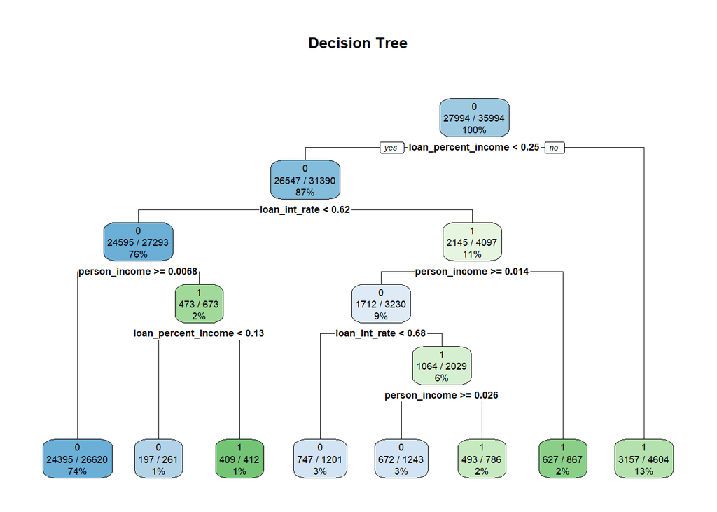

```r
# Visualize the decision tree
rpart.plot(decision_tree_model, type = 2, extra = 102, main = "Decision Tree")
```

```r
# Predictions on the test set
decision_tree_predictions <- predict(decision_tree_model, data.frame(X_test), type = "class")

# Model evaluation
confusion <- confusionMatrix(decision_tree_predictions, y_test)
print(confusion)
```

```
## Confusion Matrix and Statistics
##
##           Reference
## Prediction    0    1
##          0 6492  840
##          1  506 1160
##
##                Accuracy : 0.8504
##                  95% CI : (0.8429, 0.8577)
##     No Information Rate : 0.7777
##     P-Value [Acc > NIR] : < 2.2e-16
##
##                   Kappa : 0.5399
##
##  Mcnemar's Test P-Value : < 2.2e-16
##
##             Sensitivity : 0.9277
##             Specificity : 0.5800
##          Pos Pred Value : 0.8854
##          Neg Pred Value : 0.6963
##              Prevalence : 0.7777
##          Detection Rate : 0.7215
##    Detection Prevalence : 0.8148
##       Balanced Accuracy : 0.7538
##
##        'Positive' Class : 0
##
```

**With categorical data**

```r
library(rpart)
library(rpart.plot)

# Train the decision tree model
set.seed(42)
decision_tree_model <- rpart(
  formula = y_train2 ~ .,  # Formula: y_train2 as the dependent variable and all columns of X_train2 as independent variables
  data = data.frame(X_train2, y_train2),  # Create a data frame combining X_train2 and y_train2
  method = "class"  # Method for classification
)

# Model summary
print(decision_tree_model)
```

```
## n= 35994
##
## node), split, n, loss, yval, (yprob)
##       * denotes terminal node
##
##  1) root 35994 8000 0 (0.7777407 0.2222593)
##    2) previous_loan_defaults_on_file=Yes 18273    0 0 (1.0000000 0.0000000) *
##    3) previous_loan_defaults_on_file=No 17721 8000 0 (0.5485582 0.4514418)
##      6) loan_percent_income< 0.245 14098 4843 0 (0.6564761 0.3435239)
##       12) loan_int_rate< 0.5764746 10632 2372 0 (0.7768999 0.2231001)
##         24) person_income>=0.006798773 10127 1933 0 (0.8091241 0.1908759) *
##         25) person_income< 0.006798773 505   66 1 (0.1306931 0.8693069) *
##       13) loan_int_rate>=0.5764746 3466  995 1 (0.2870744 0.7129256)
##         26) loan_intent=EDUCATION,PERSONAL,VENTURE 1523  669 1 (0.4392646 0.5607354)
##           52) person_home_ownership=MORTGAGE,OTHER,OWN 550  189 0 (0.6563636 0.3436364) *
##           53) person_home_ownership=RENT 973  308 1 (0.3165468 0.6834532) *
##         27) loan_intent=DEBTCONSOLIDATION,HOMEIMPROVEMENT,MEDICAL 1943  326 1 (0.1677818 0.8322182) *
##      7) loan_percent_income>=0.245 3623  466 1 (0.1286227 0.8713773)
##       14) person_home_ownership=MORTGAGE,OWN 776  344 0 (0.5567010 0.4432990)
##         28) person_income>=0.007017361 699  267 0 (0.6180258 0.3819742)
##           56) loan_int_rate< 0.5730453 501  126 0 (0.7485030 0.2514970) *
##           57) loan_int_rate>=0.5730453 198   57 1 (0.2878788 0.7121212) *
##         29) person_income< 0.007017361 77    0 1 (0.0000000 1.0000000) *
##       15) person_home_ownership=OTHER,RENT 2847   34 1 (0.0119424 0.9880576) *
```

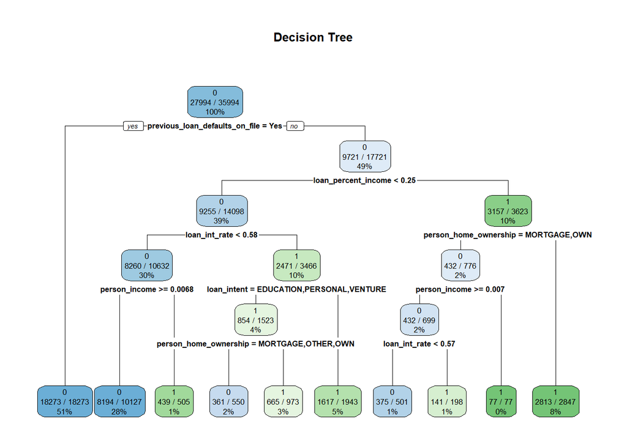

```r
# Visualize the decision tree
rpart.plot(decision_tree_model, type = 2, extra = 102, main = "Decision Tree")
```

```r
# Predictions on the test set
decision_tree_predictions <- predict(decision_tree_model, data.frame(X_test2), type = "class")

# Model evaluation
confusion <- confusionMatrix(decision_tree_predictions, y_test2)
print(confusion)
```

```
## Confusion Matrix and Statistics
##
##           Reference
## Prediction    0    1
##          0 6781  569
##          1  217 1431
##
##                Accuracy : 0.9126
##                  95% CI : (0.9066, 0.9184)
##     No Information Rate : 0.7777
##     P-Value [Acc > NIR] : < 2.2e-16
##
##                   Kappa : 0.7304
##
##  Mcnemar's Test P-Value : < 2.2e-16
##
##             Sensitivity : 0.9690
##             Specificity : 0.7155
##          Pos Pred Value : 0.9226
##          Neg Pred Value : 0.8683
##              Prevalence : 0.7777
##          Detection Rate : 0.7536
##    Detection Prevalence : 0.8168
##       Balanced Accuracy : 0.8422
##
##        'Positive' Class : 0
##
```

**With K-Fold Cross Validation**

In this case, we conducted two experiments: one without categorical data and another including categorical data.

**Without categorical data**

```r
# Set up K-Fold cross-validation
set.seed(42)
kfold_control <- trainControl(method = "cv", number = 5)

# Train the decision tree model with K-Fold
set.seed(42)
decision_tree_model <- train(
  x = X_train,
  y = y_train,
  method = "rpart",  # Method for decision tree in caret
  trControl = kfold_control,
  metric = "Accuracy",  # Evaluation metric
  tuneGrid = expand.grid(cp = seq(0.01, 0.1, by = 0.01))  # Test different complexity parameter (cp) values
)

# Print the model results
print(decision_tree_model)
```

```
## CART
##
## 35994 samples
##     8 predictor
##     2 classes: '0', '1'
##
## No pre-processing
## Resampling: Cross-Validated (5 fold)
## Summary of sample sizes: 28795, 28795, 28795, 28796, 28795
## Resampling results across tuning parameters:
##
##   cp    Accuracy   Kappa
##   0.01  0.8512806  0.5505358
##   0.02  0.8432515  0.5058645
##   0.03  0.8252485  0.4041810
##   0.04  0.8252485  0.4041810
##   0.05  0.8252485  0.4041810
##   0.06  0.8252485  0.4041810
##   0.07  0.8252485  0.4041810
##   0.08  0.8252485  0.4041810
##   0.09  0.8252485  0.4041810
##   0.10  0.8252485  0.4041810
##
## Accuracy was used to select the optimal model using the largest value.
## The final value used for the model was cp = 0.01.
```

```r
# Best hyperparameter (cp)
cat("Best cp value:", decision_tree_model$bestTune$cp, "\n")
```

```
## Best cp value: 0.01
```

```r
# Predictions on the test set
tree_predictions <- predict(decision_tree_model, X_test)

# Model evaluation
confusion <- confusionMatrix(tree_predictions, y_test)
print(confusion)
```

```
## Confusion Matrix and Statistics
##
##           Reference
## Prediction    0    1
##          0 6492  840
##          1  506 1160
##
##                Accuracy : 0.8504
##                  95% CI : (0.8429, 0.8577)
##     No Information Rate : 0.7777
##     P-Value [Acc > NIR] : < 2.2e-16
##
##                   Kappa : 0.5399
##
##  Mcnemar's Test P-Value : < 2.2e-16
##
##             Sensitivity : 0.9277
##             Specificity : 0.5800
##          Pos Pred Value : 0.8854
##          Neg Pred Value : 0.6963
##              Prevalence : 0.7777
##          Detection Rate : 0.7215
##    Detection Prevalence : 0.8148
##       Balanced Accuracy : 0.7538
##
##        'Positive' Class : 0
##
```

**With categorical data**

```r
# Set up K-Fold cross-validation
set.seed(42)
kfold_control <- trainControl(method = "cv", number = 5)

# Train the decision tree model with K-Fold
set.seed(42)
decision_tree_model <- train(
  x = X_train2,
  y = y_train2,
  method = "rpart",  # Method for decision tree in caret
  trControl = kfold_control,
  metric = "Accuracy",  # Evaluation metric
  tuneGrid = expand.grid(cp = seq(0.01, 0.1, by = 0.01))  # Test different complexity parameter (cp) values
)

# Print the model results
print(decision_tree_model)
```

```
## CART
##
## 35994 samples
##    13 predictor
##     2 classes: '0', '1'
##
## No pre-processing
## Resampling: Cross-Validated (5 fold)
## Summary of sample sizes: 28795, 28795, 28795, 28796, 28795
## Resampling results across tuning parameters:
##
##   cp    Accuracy   Kappa
##   0.01  0.9090679  0.7188826
##   0.02  0.9039005  0.7156368
##   0.03  0.9039005  0.7156368
##   0.04  0.9039005  0.7156368
##   0.05  0.8933431  0.6768125
##   0.06  0.8933431  0.6768125
##   0.07  0.8933431  0.6768125
##   0.08  0.8933431  0.6768125
##   0.09  0.8933431  0.6768125
##   0.10  0.8933431  0.6768125
##
## Accuracy was used to select the optimal model using the largest value.
## The final value used for the model was cp = 0.01.
```

```r
# Best hyperparameter (cp)
cat("Best cp value:", decision_tree_model$bestTune$cp, "\n")
```

```
## Best cp value: 0.01
```

```r
# Predictions on the test set
tree_predictions <- predict(decision_tree_model, X_test2)

# Model evaluation
confusion <- confusionMatrix(tree_predictions, y_test2)
print(confusion)
```

```
## Confusion Matrix and Statistics
##
##           Reference
## Prediction    0    1
##          0 6781  569
##          1  217 1431
##
##                Accuracy : 0.9126
##                  95% CI : (0.9066, 0.9184)
##     No Information Rate : 0.7777
##     P-Value [Acc > NIR] : < 2.2e-16
##
##                   Kappa : 0.7304
##
##  Mcnemar's Test P-Value : < 2.2e-16
##
##             Sensitivity : 0.9690
##             Specificity : 0.7155
##          Pos Pred Value : 0.9226
##          Neg Pred Value : 0.8683
##              Prevalence : 0.7777
##          Detection Rate : 0.7536
##    Detection Prevalence : 0.8168
##       Balanced Accuracy : 0.8422
##
##        'Positive' Class : 0
##
```

**Conclusion**

The results show that decision tree models improve significantly when categorical data is included. In models without categorical variables, sensitivity is high (92.77%), but specificity is low (58.00%), indicating an imbalance in classification. When categorical variables are incorporated, both sensitivity (96.90%) and specificity (71.55%) increase significantly, resulting in a more balanced accuracy (91.26% accuracy, Balanced Accuracy = 84.22%). This highlights the importance of considering all relevant variables in the model. Additionally, higher Kappa values with categorical data reflect better consistency in predictions. Finally, cross-validation confirms the stability of the model’s performance.

## **4. Main Conclusion**

This assignment set out to develop predictive models to classify loan approval statuses by thoroughly analyzing and processing a dataset, followed by implementing machine learning techniques. Through the process, a comprehensive understanding of the dataset and the models was achieved, leading to insightful conclusions and the successful completion of the proposed objectives.

The first step involved a detailed Exploratory Data Analysis (EDA). Key features were analyzed for distributions, correlations, and potential anomalies. Missing values were addressed, and outliers—such as unrealistic ages and excessive work experience—were identified and removed. Relationships between variables were explored, revealing significant correlations, like the one between age and credit history length, and their impact on the model’s performance.

The evaluation of these models revealed that **decision trees** were the most effective in balancing predictive performance and interpretability, making them ideal for this classification task. K-fold cross-validation emerged as an invaluable technique for robust model assessment and hyperparameter optimization.

The assignment provided critical insights into the importance of data preparation and feature engineering. Addressing outliers and leveraging the full potential of categorical variables were decisive factors in the success of the models. Moreover, the comparison between normalization techniques underscored the impact of preprocessing on models like K-NN, which rely on distance metrics.

In conclusion, this project achieved its objectives by constructing and evaluating predictive models for loan approval classification. The decision tree model, particularly when trained with categorical variables, proved to be the best-performing and most interpretable solution. This process reinforced the value of systematic data analysis, preprocessing, and validation in developing effective machine learning models.